# HW: Week 15 – Solutions

36-350 – Statistical Computing

Week 15 – Spring 2019

Name: Carl Yang Andrew ID: yufeiy3

This HW is to be begun in class, but may be finished outside of class at any time prior to Friday, May 3<sup>rd</sup> at 5:00 PM. You must submit **your own** lab as a knitted HTML file on the Canvas course page.

In this homework, you will be working with Sean Lahman’s baseball statistics database, which contains data from 1871 up through 2016. (More recent data are available, but not yet in `SQLite` format.) Download the file `lahman2016.sqlite` from the `Canvas` site, from under `Files/MATERIALS/Week_15`, if you have not done so already.

Note that this homework does function somewhat like a `SQL Project` in that *you will not be pointed to specific slides of Notes 13 and 14*…but you will have to apply the material you learned from Notes 13 and 14 here.

## Question 1

*(5 points)*

*Notes 15A (3-4)*

Establish a connection to the Lahman database and list its tables.

```r
if ( require(DBI) == FALSE ) {
  install.packages("DBI",repos="https://cloud.r-project.org")
  library(DBI)
}
if ( require(RSQLite) == FALSE ) {
  install.packages("RSQLite",repos="https://cloud.r-project.org")
  library(RSQLite)
}
drv = dbDriver("SQLite")
con = dbConnect(drv,dbname="./lahman2016.sqlite")
dbListTables(con)
```

```
##  [1] "AllstarFull"         "Appearances"         "AwardsManagers"
##  [4] "AwardsPlayers"       "AwardsShareManagers" "AwardsSharePlayers"
##  [7] "Batting"             "BattingPost"         "CollegePlaying"
## [10] "Fielding"            "FieldingOF"          "FieldingOFsplit"
## [13] "FieldingPost"        "HallOfFame"          "HomeGames"
## [16] "Managers"            "ManagersHalf"        "Master"
## [19] "Parks"               "Pitching"            "PitchingPost"
## [22] "Salaries"            "Schools"             "SeriesPost"
## [25] "Teams"               "TeamsFranchises"     "TeamsHalf"
```

## Question 2

*(10 points)*

*Notes 15A (4-6)*

List all ballparks that teams in Philadelphia have played in, in alphabetical order. (Note: use `parkname` for the ballpark name.)

```r
dbGetQuery(con, "SELECT parkname
                      FROM Parks
                      WHERE city = 'Philadelphia'
                      ORDER BY parkname ASC")
```

```
##                              parkname
## 1                          Baker Bowl
## 2                     Centennial Park
## 3                  Citizens Bank Park
## 4                       Columbia Park
## 5                      Forepaugh Park
## 6                Huntingdon Grounds I
## 7               Huntingdon Grounds II
## 8            Jefferson Street Grounds
## 9                       Keystone Park
## 10                       Oakdale Park
## 11                    Recreation Park
## 12                         Shibe Park
## 13 University of Penn. Athletic Field
## 14                   Veterans Stadium
```

## Question 3

*(10 points)*

*Notes 15A (4-6)*

List the five winningest managers of all time, and the cumulative number of wins for each. Note: managers have unique `playerID` values; there is no `managerID`.

```r
dbGetQuery(con, "SELECT playerID, sum(W) as SUM
                      FROM Managers
                      GROUP BY playerID
                      ORDER BY sum(W) DESC
                      LIMIT 5")
```

```
##    playerID  SUM
## 1  mackco01 3731
## 2 mcgrajo01 2763
## 3 larusto01 2728
## 4   coxbo01 2504
## 5 torrejo01 2326
```

## Question 4

*(10 points)*

*Notes 15A (4-6)*

List all pitchers with 300 or more wins in their careers, along with their cumulative wins *and* losses, ordered by the number of wins. Use the `Pitching` table. Rename the sum of wins as `W` and the sum of losses as `L`.

```r
#dbListFields(con, "Pitching")
dbGetQuery(con, "SELECT playerID, sum(W) as W, sum(L) as L
                      FROM Pitching
                      GROUP BY playerID
                      HAVING sum(W) >=300
                      ORDER BY sum(W) DESC")
```

```
##     playerID   W   L
## 1  youngcy01 511 316
## 2  johnswa01 417 279
## 3  alexape01 373 208
## 4  mathech01 373 188
## 5  galvipu01 364 310
## 6  spahnwa01 363 245
## 7  nichoki01 361 208
## 8  maddugr01 355 227
## 9  clemero02 354 184
## 10 keefeti01 342 225
## 11 carltst01 329 244
## 12 clarkjo01 328 178
## 13 planked01 326 194
## 14  ryanno01 324 292
## 15 suttodo01 324 256
## 16 niekrph01 318 274
## 17 perryga01 314 265
## 18 seaveto01 311 205
## 19 radboch01 309 195
## 20 welchmi01 307 210
## 21 glavito02 305 203
## 22 johnsra05 303 166
## 23 grovele01 300 141
## 24  wynnea01 300 244
```

## Question 5

*(10 points)*

*Notes 15A (4-6)*

List the top five major league batting averages in 2016, among all players that had at least 200 at bats. A few notes: batting average is `h` divided by `AB` in `Batting`; to force floating point division, multiply `h` by 1.0; round your quotient off to three decimal places; and rename your calculated column as `ba`.

```r
dbGetQuery(con, "SELECT ROUND((h*1.0/AB), 3) as batting_avg
                      FROM Batting
                      WHERE yearID = 2016 AND AB >= 200
                      ORDER BY batting_avg DESC
                      limit 5")
```

```
##   batting_avg
## 1       0.348
## 2       0.347
## 3       0.342
## 4       0.338
## 5       0.326
```

## Question 6

*(10 points)*

*Notes 15A (4-7)*

What ten players had the highest salaries during seasons in which they made the All-Star Game? Use the `AllstarFull` and `Salaries` tables to determine this, and list the player IDs, the years, and the salaries.

```r
dbGetQuery(con, "SELECT playerID, yearID, salary
                      FROM AllstarFull JOIN Salaries USING(playerID,yearID)
                      ORDER BY salary DESC
                      limit 10")
```

```
##     playerID yearID   salary
## 1  rodrial01   2010 33000000
## 2  kershcl01   2016 33000000
## 3  kershcl01   2015 32571000
## 4  rodrial01   2011 32000000
## 5  rodrial01   2008 28000000
## 6  cabremi01   2016 28000000
## 7  cespeyo01   2016 27328046
## 8  rodrial01   2005 26000000
## 9  greinza01   2014 26000000
## 10   leecl02   2013 25000000
```

## Question 7

*(10 points)*

*Notes 15A (4-7)*

Repeat Q6, except instead of listing the player IDs, list the player first names and player last names. These may be found in the `Master` table. Note: this requires chaining two `JOIN`s.

```r
dbGetQuery(con, "SELECT nameFirst, nameLast, yearID, salary
                      FROM AllstarFull
                      JOIN Salaries USING(playerID,yearID)
                      JOIN Master USING(playerID)
                      ORDER BY salary DESC
                      limit 10")
```

```
##    nameFirst  nameLast yearID   salary
## 1       Alex Rodriguez   2010 33000000
## 2    Clayton   Kershaw   2016 33000000
## 3    Clayton   Kershaw   2015 32571000
## 4       Alex Rodriguez   2011 32000000
## 5       Alex Rodriguez   2008 28000000
## 6     Miguel   Cabrera   2016 28000000
## 7     Yoenis  Cespedes   2016 27328046
## 8       Alex Rodriguez   2005 26000000
## 9       Zack   Greinke   2014 26000000
## 10     Cliff       Lee   2013 25000000
```

## Question 8

*(10 points)*

*Notes 15A (4-7)*

Compute the slugging percentages of players during the years that they won the Triple Crown.

The slugging percentage is the total number of bases a player gains from hitting divided by the total number of at-bats. If you look in the `Batting` table, there are fields dubbed `H` (for overall number of hits), `2B` (for doubles: two bases gained), `3B` (for triples: three bases gained), `HR` (for home runs: four bases gained), and `AB` (for at-bats). To determine the number of singles (hits with one base gained), substract the number of doubles, triples, and home runs from the overall number of hits.

To limit yourself to Triple Crown winners (highest batting average, number of home runs, and number of runs batted in in the same season), you want to join the `Batting` table with the `AwardsPlayers` table and keep those rows of output wherein `awardID=‘Triple Crown’`. In the end, show the `playerID`, the `yearID`, and the slugging percentage (named `slugging`), rounded to three decimal places.

(Hint: you may have to surround certain field names with *square brackets* so as not to confuse the `SQLite` parser when computing the slugging percentage. Specifically: the field names with numbers in them.)

If you do this all correctly, you should get 17 rows output, the last being for Miguel Cabrera (`cabremi01`) in 2012, with a 0.606 slugging percentage.

```r
dbGetQuery(con, "SELECT playerID, yearID, ROUND(((H-[2B]-[3B]-[HR])+[2B]*2.0+[3B]*3.0+[HR]*4.0)/AB, 3) as slugging
                      FROM Batting
                      JOIN AwardsPlayers USING(playerID, yearID)
                      WHERE awardID='Triple Crown'")
```

```
##     playerID yearID slugging
## 1  hinespa01   1878    0.486
## 2  oneilti01   1887    0.691
## 3  duffyhu01   1894    0.694
## 4  lajoina01   1901    0.643
## 5   cobbty01   1909    0.517
## 6  hornsro01   1922    0.722
## 7  hornsro01   1925    0.756
## 8   foxxji01   1933    0.703
## 9  kleinch01   1933    0.602
## 10 gehrilo01   1934    0.706
## 11 medwijo01   1937    0.641
## 12 willite01   1942    0.648
## 13 willite01   1947    0.634
## 14 mantlmi01   1956    0.705
## 15 robinfr02   1966    0.637
## 16 yastrca01   1967    0.622
## 17 cabremi01   2012    0.606
```

## Question 9

*(10 points)*

*Notes 15A (4-6)*

Here we will combine database work with plotting. Compute the total salary paid to players in each year since (and including) 1990, and plot this number (which you should call `totalSalary`) versus year. You should see that earlier this decade, the total salary passed three *billion* dollars per year. (Which is a lot…but on the other hand, Jeff Bezos could still pay all major league baseball players by himself. If he felt so compelled.)

```r
database = dbGetQuery(con, "SELECT yearID, sum(salary) as totalSalary
                      FROM Salaries
                      WHERE yearID >= 1990
                      GROUP BY yearID")
database
```

```
##    yearID totalSalary
## 1    1990   443881193
## 2    1991   613048418
## 3    1992   805543323
## 4    1993   901740134
## 5    1994   927836287
## 6    1995   951469367
## 7    1996   956983550
## 8    1997  1127285885
## 9    1998  1278282871
## 10   1999  1494228750
## 11   2000  1666135102
## 12   2001  1960663313
## 13   2002  2024077522
## 14   2003  2128262128
## 15   2004  2070665943
## 16   2005  2188713398
## 17   2006  2321472617
## 18   2007  2476688987
## 19   2008  2684858670
## 20   2009  2664726994
## 21   2010  2721359865
## 22   2011  2784505291
## 23   2012  2932741192
## 24   2013  3034525648
## 25   2014  3192317623
## 26   2015  3514142569
## 27   2016  3750137392
```

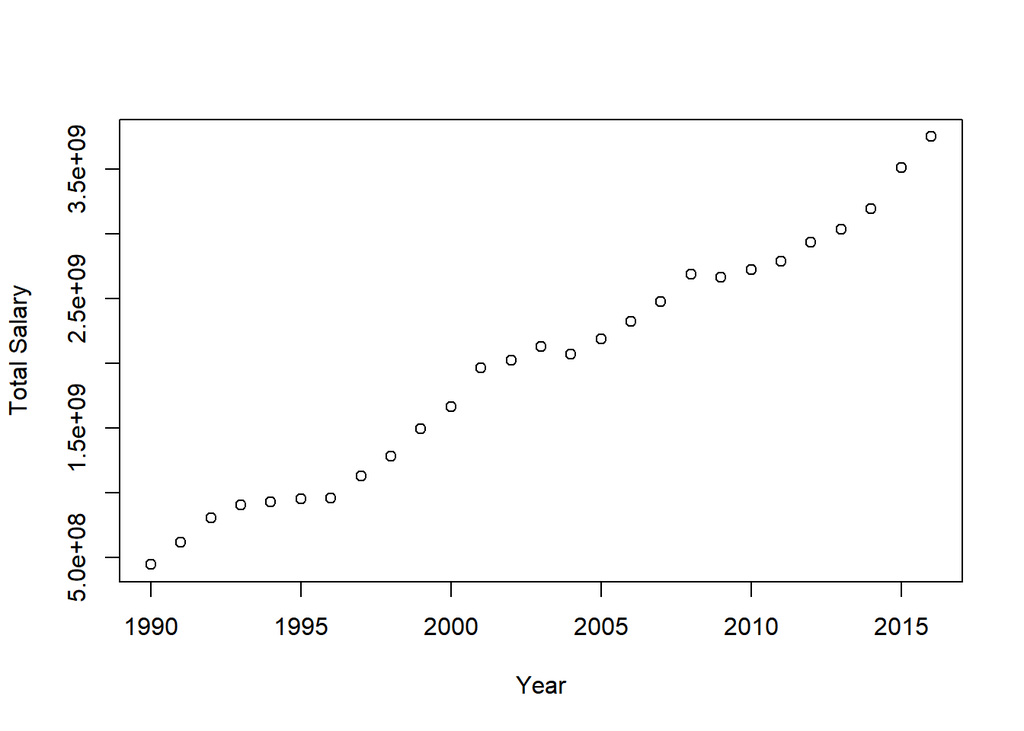

```r
plot(database$year, database$totalSalary, xlab = "Year", ylab = "Total Salary")
```

## Question 10

*(10 points)*

*Notes 15A (4-6)*

One last question: who had the longest career? You might think that you should simply count the number of rows for each player and determine the maximum, but no, not here. In the `Master` table, there are two specific fields: `debut` and `finalGame`. Pull out this information, along with `nameFirst` and `nameLast`, and then use, e.g., `dplyr` functions to compute the number of days between debut and final game, and to arrange the output in order of the number of days, descending. Show the first ten rows of output only. (Hint: Google `as.Date()`…this can simplify the calculation immensely. Do not code your own “convert two dates to a difference in days” function.)

```r
library(tidyverse)
library(dplyr)
result = dbGetQuery(con, "SELECT nameFirst, nameLast, finalGame, debut
                      FROM Master")
df = data.frame(result$nameFirst, result$nameLast, as.Date(result$finalGame)-as.Date(result$debut))
colnames(df)[1] = "first name"
colnames(df)[2] = "last name"
colnames(df)[3] = "days"
df %>% arrange(., desc(days)) %>% head(10)
```

```
##    first name last name       days
## 1        Nick   Altrock 12862 days
## 2         Jim  O'Rourke 11836 days
## 3      Minnie    Minoso 11492 days
## 4     Charley   O'Leary 11126 days
## 5       Arlie    Latham 10678 days
## 6      Deacon   McGuire 10192 days
## 7      Hughie  Jennings  9954 days
## 8      Johnny     Evers  9897 days
## 9       Nolan      Ryan  9873 days
## 10      Gabby    Street  9868 days
```

## Question 11

*(5 points)*

*Use Google or look at the RSQLite documentation*

Finish things off by disconnecting from `SQLite`.

```r
dbDisconnect(con)
```